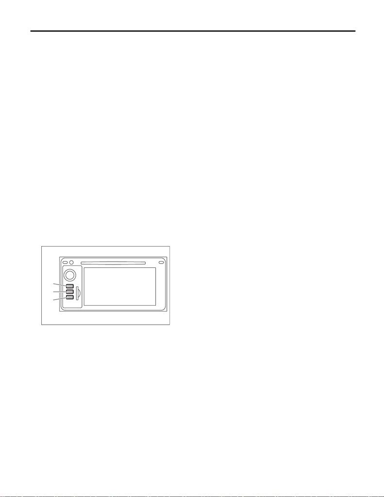

ET-5

Navigation System

ENTERTAINMENT

4. Navigation System

A: WIRING DIAGRAM

Refer to “Navigation System” in the wiring diagram.

• ENGINE TYPE FA: <Ref. to WI-303, ENGINE TYPE FA, WIRING DIAGRAM, Navigation System.>

• ENGINE TYPE EJ: <Ref. to WI-309, ENGINE TYPE EJ, WIRING DIAGRAM, Navigation System.>

B: INSPECTION

NOTE:

If no problems are found in “CHECK NAVIGATION OPERATION”, “CHECK EACH CONNECTION” and

“CHECK EACH VEHICLE SIGNAL” as described below, check the navigation system circuit.

• ENGINE TYPE FA: <Ref. to WI-303, ENGINE TYPE FA, WIRING DIAGRAM, Navigation System.>

• ENGINE TYPE EJ: <Ref. to WI-309, ENGINE TYPE EJ, WIRING DIAGRAM, Navigation System.>

1. CHECK NAVIGATION OPERATION

Start the engine and check that the opening screen is displayed.

Standard: Opening screen is displayed.

OK: Normal.

NG: If the screen is not displayed, check the following items.

• The map disk (SD CARD) is set in the navigation system unit.

• Check the connection of the power supply connector at the backside of the navigation unit. If wire connec-

tion is correct or has got repaired, check again that the opening screen is displayed.

If it is not displayed at this time, it indicates the navigation unit trouble.

2. CHECK EACH CONNECTION

1) With the main power OFF, press and hold the button (c) for 3 seconds or more while pressing the buttons

(a) and (b) simultaneously.

NOTE:

Pressing the button (a) for 3 seconds or more, or turning the ignition from ACC OFF to ON position can exit

the diagnostic mode.

2) Line Diag screen is displayed.

ET-00672

(a)

(b)

(c)

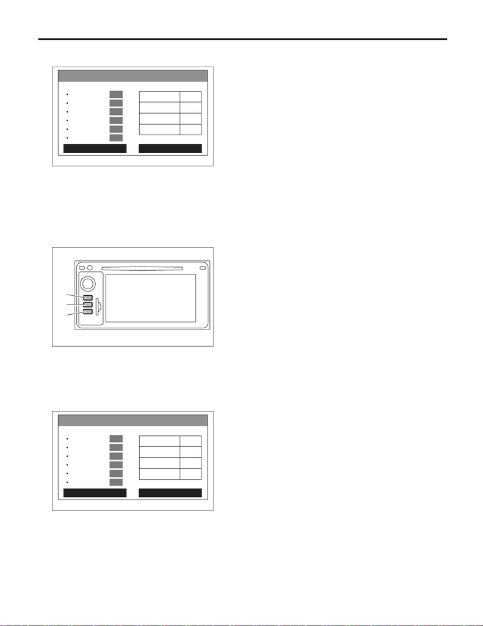

ET-6

Navigation System

ENTERTAINMENT

3) Check the connection status for each item listed in “Connectivity Check” displayed on the left of the

screen.

OK: Each connection device is connected properly.

NG: No connection or abnormal connection is detected.

4) Check the connection status of the connector. If there are no problems, the connection device or unit could

be faulty.

3. CHECK EACH VEHICLE SIGNAL

1) With the main power OFF, press and hold the button (c) for 3 seconds or more while pressing the buttons

(a) and (b) simultaneously.

NOTE:

Pressing the button (a) for 3 seconds or more, or turning the ignition from ACC OFF to ON position can exit

the diagnostic mode.

2) Line Diag screen is displayed.

3) Check the connection status for each item listed in “Vehicle Signal Check” displayed on the right of the

screen.

ET-00677

Camera Setting

Audio Check

Line Diag

OK

GPS

OK

MIC

NG

Rr_CAM

OK

AUX

OK

USB

OK

SAT

Connectivity Check Vehicle Signal Check

ILL

+

SPD

PKB

REV

OFF

OFF

ON

OFF

ET-00672

(a)

(b)

(c)

Camera Setting

Audio Check

Line Diag

OK

GPS

OK

MIC

NG

Rr_CAM

OK

AUX

OK

USB

OK

SAT

Connectivity Check Vehicle Signal Check

ILL

+

SPD

PKB

REV

OFF

OFF

ON

OFF

[figure not shown]

ET-7

Navigation System

ENTERTAINMENT

• Check illumination

NOTE:

Before starting inspections, turn the ignition to ON.

1) Set the lighting switch to TAIL (small) position.

Make sure that the bright switch is not turned ON at this time.

2) Make sure that “ON” lights in ILL+ and then the screen becomes dim.

ON: Normal

OFF: Abnormal Check the signal line connector. If there are no problems, the unit could be faulty.

• Check speed sensor

NOTE:

• Before starting inspections, check the safety around the vehicle.

• Lift up the vehicle as necessary.

• When the diagnostic trouble code is input in the VDC CM, perform the Clear Memory operation.

1) Drive the vehicle at 9 km/h (6 MPH) or more.

2) Check that “ON” is displayed in SPD.

ON: Normal

OFF: Vehicle speed is less than 7 km/h (4 MPH), or malfunction is detected in the signal line. Check the sig-

nal line connector. If there are no problems, the unit could be faulty.

• Check parking brake signal

1) Pull parking brake lever.

2) Check that “ON” is displayed in PKB.

ON: Normal

OFF: Abnormal Check the signal line connector. If there are no problems, the unit could be faulty.

• Check back sensor

NOTE:

Before starting inspections, check the safety around the rear end of the vehicle and then turn the ignition to

ON.

1) Pull the parking brake and depress the brake, then put the gear in reverse.

2) Make sure that “ON” is displayed in REV.

ON: Normal

OFF: Abnormal Check the signal line connector. If there are no problems, the unit could be faulty.

C: NOTE

For procedure of each component in the navigation system, refer to the respective section.

• Navigation unit: <Ref. to ET-19, Navigation Body.>

• GPS antenna: <Ref. to ET-20, GPS Antenna.>

• Rearview camera: <Ref. to ET-21, Rearview Camera System.>